# Reinforcement Learning for Smart Home EV Charging Optimization

# 8.0 Deep Q-learning (DQN) baseline

# 8.1 Replay buffer and Q-network architecture

Defines a replay buffer class that stores individual transitions in the form $(s,a,r,s',done)$ and supports random minibatch sampling. The Q-network is a fully connected feedforward neural network that maps the continuous observation vector to a length $∣A∣$ vector of Q-values, one for each discrete charging power level. The architecture typically consists of two or three hidden layers with ReLU activations. The network parameters live on the chosen `device` and are optimised with Adam.

```python
class ReplayBuffer:
    """
    Simple experience replay buffer for off-policy value-based RL.

    Each entry is a transition tuple (s, a, r, s_next, done).
    """

    def __init__(self, capacity: int, obs_dim: int):
        self.capacity = capacity
        self.obs_buf = np.zeros((capacity, obs_dim), dtype=np.float32)
        self.next_obs_buf = np.zeros((capacity, obs_dim), dtype=np.float32)
        self.act_buf = np.zeros(capacity, dtype=np.int64)
        self.rew_buf = np.zeros(capacity, dtype=np.float32)
        self.done_buf = np.zeros(capacity, dtype=np.float32)
        self.idx = 0
        self.size = 0

    def add(self, obs, action, reward, next_obs, done):
        i = self.idx
        self.obs_buf[i] = obs
        self.next_obs_buf[i] = next_obs
        self.act_buf[i] = action
        self.rew_buf[i] = reward
        self.done_buf[i] = float(done)

        self.idx = (self.idx + 1) % self.capacity
        self.size = min(self.size + 1, self.capacity)

    def sample(self, batch_size: int):
        assert self.size >= batch_size
        idxs = np.random.randint(0, self.size, size=batch_size)
        batch = dict(
            obs=self.obs_buf[idxs],
            next_obs=self.next_obs_buf[idxs],
            acts=self.act_buf[idxs],
            rews=self.rew_buf[idxs],
            dones=self.done_buf[idxs],
        )
        return batch

    def __len__(self):
        return self.size


class QNetwork(nn.Module):
    """
    Small feed-forward neural network for approximating Q(s, a).

    The architecture uses two hidden layers with ReLU activations.
    Given a state vector s, it outputs a vector of Q-values, one for
    each discrete action.
    """

    def __init__(self, obs_dim: int, n_actions: int, hidden_sizes=(64, 64)):
        super().__init__()
        layers = []
        input_dim = obs_dim
        for h in hidden_sizes:
            layers.append(nn.Linear(input_dim, h))
            layers.append(nn.ReLU())
            input_dim = h
        layers.append(nn.Linear(input_dim, n_actions))
        self.net = nn.Sequential(*layers)

    def forward(self, x: torch.Tensor) -> torch.Tensor:
        return self.net(x)
```

# 8.2 DQN agent and learning rule

Encapsulates the DQN algorithm in a `DqnAgent` class. The agent maintains an online Q-network and a separate target network, implements epsilon-greedy exploration with a decaying exploration rate $𝜖_𝑡$, and performs Bellman updates using minibatches drawn from the replay buffer. For each sampled transition, the agent computes the temporal-difference target $r +\gamma \max_{a'} Q_{\text{target}}(s', a') $and minimises the mean-squared error between this target and the online Q-value $Q_{θ} (s,a)$. Periodic hard updates copy the online network weights to the target network to improve stability.

```python
class DqnAgent:
    """
    Deep Q-learning agent with epsilon-greedy exploration and a target network.
    """

    def __init__(
        self,
        obs_dim: int,
        n_actions: int,
        device: torch.device,
        gamma: float = 0.99,
        lr: float = 1e-3,
        epsilon_start: float = 1.0,
        epsilon_end: float = 0.05,
        epsilon_decay_episodes: int = 400,
        replay_capacity: int = 50_000,
        batch_size: int = 64,
        target_update_interval: int = 50,
    ):
        self.device = device
        self.gamma = gamma
        self.batch_size = batch_size
        self.target_update_interval = target_update_interval

        self.online_net = QNetwork(obs_dim, n_actions).to(device)
        self.target_net = QNetwork(obs_dim, n_actions).to(device)
        self.target_net.load_state_dict(self.online_net.state_dict())

        self.optimizer = optim.Adam(self.online_net.parameters(), lr=lr)

        self.replay = ReplayBuffer(replay_capacity, obs_dim)

        # Epsilon-greedy exploration schedule
        self.epsilon_start = epsilon_start
        self.epsilon_end = epsilon_end
        self.epsilon_decay_episodes = max(1, epsilon_decay_episodes)
        self.episode_count = 0

        self.n_actions = n_actions

    def epsilon(self) -> float:
        """
        Compute the current epsilon value based on the number of episodes
        completed so far, decaying linearly from epsilon_start to epsilon_end.
        """
        frac = min(1.0, self.episode_count / self.epsilon_decay_episodes)
        return self.epsilon_start + frac * (self.epsilon_end - self.epsilon_start)

    def select_action(self, obs: np.ndarray, explore: bool = True) -> int:
        """
        Epsilon-greedy action selection given the current observation.
        """
        if explore and np.random.rand() < self.epsilon():
            return np.random.randint(self.n_actions)

        obs_t = torch.tensor(obs, dtype=torch.float32, device=self.device).unsqueeze(0)
        with torch.no_grad():
            q_values = self.online_net(obs_t)  # shape [1, n_actions]
        action = int(q_values.argmax(dim=1).item())
        return action

    def store_transition(self, obs, action, reward, next_obs, done):
        self.replay.add(obs, action, reward, next_obs, done)

    def train_step(self):
        if len(self.replay) < self.batch_size:
            return {}

        batch = self.replay.sample(self.batch_size)
        obs = torch.tensor(batch["obs"], dtype=torch.float32, device=self.device)
        next_obs = torch.tensor(batch["next_obs"], dtype=torch.float32, device=self.device)
        acts = torch.tensor(batch["acts"], dtype=torch.long, device=self.device).unsqueeze(-1)
        rews = torch.tensor(batch["rews"], dtype=torch.float32, device=self.device).unsqueeze(-1)
        dones = torch.tensor(batch["dones"], dtype=torch.float32, device=self.device).unsqueeze(-1)

        # Q-values for actions taken
        q_values = self.online_net(obs).gather(1, acts)

        # Target Q-values using target network and max over actions
        with torch.no_grad():
            next_q_values = self.target_net(next_obs)
            max_next_q = next_q_values.max(dim=1, keepdim=True)[0]
            target_q = rews + self.gamma * (1.0 - dones) * max_next_q

        loss = nn.MSELoss()(q_values, target_q)

        self.optimizer.zero_grad()
        loss.backward()
        self.optimizer.step()

        return {"loss": float(loss.item())}

    def update_target_network(self):
        self.target_net.load_state_dict(self.online_net.state_dict())
```

# 8.3 Training DQN on the EV environment

Runs a DQN training loop on `SmartEvChargingEnv` for a specified number of episodes. At each step within an episode, the agent selects an action via epsilon-greedy, interacts with the environment, stores the transition, and performs gradient updates once a minimum replay buffer size is reached. The loop records per-episode returns, nightly costs, final SoCs, and shortfall indicators. Periodic log messages report these statistics so that training progress can be monitored numerically.

```python
def train_dqn_on_ev_env(
    n_episodes: int = 600,
    gamma: float = 0.99,
    lr: float = 1e-3,
    epsilon_start: float = 1.0,
    epsilon_end: float = 0.05,
    epsilon_decay_episodes: int = 400,
    batch_size: int = 64,
    replay_capacity: int = 50_000,
    target_update_interval: int = 50,
) -> tuple[DqnAgent, pd.DataFrame]:
    """
    Train a DQN agent on the SmartEvChargingEnv for a specified number of episodes.

    Returns the trained agent and a DataFrame containing per-episode statistics.
    """
    # Create a dedicated training environment
    train_env = SmartEvChargingEnv(
        config=config,
        tariff_cfg=tariff_cfg,
        pv_cfg=pv_cfg,
        drive_cfg=drive_cfg,
        calendar_df=calendar_df,
        day_indices=None,
        n_action_levels=5,
        shortfall_penalty_per_kwh=0.6,
        seed=SEED,
    )

    obs_dim = train_env.observation_space.shape[0]
    n_actions = train_env.action_space.n

    agent = DqnAgent(
        obs_dim=obs_dim,
        n_actions=n_actions,
        device=device,
        gamma=gamma,
        lr=lr,
        epsilon_start=epsilon_start,
        epsilon_end=epsilon_end,
        epsilon_decay_episodes=epsilon_decay_episodes,
        replay_capacity=replay_capacity,
        batch_size=batch_size,
        target_update_interval=target_update_interval,
    )

    episode_records = []

    global_step = 0
    for ep in range(n_episodes):
        obs, info = train_env.reset()
        done = False
        agent.episode_count = ep

        ep_return = 0.0
        ep_cost = 0.0
        ep_shortfall_flag = 0

        while not done:
            action = agent.select_action(obs, explore=True)
            next_obs, reward, terminated, truncated, info = train_env.step(action)
            done = terminated or truncated

            agent.store_transition(obs, action, reward, next_obs, done)
            train_info = agent.train_step()

            obs = next_obs
            ep_return += reward
            ep_cost = info["episode_cost"]
            global_step += 1

            # Periodically sync target network
            if global_step % agent.target_update_interval == 0:
                agent.update_target_network()

        # Determine if there was a shortfall at the end of the episode
        final_soc = info["soc"]
        # Effective required SOC at the end
        required_soc_from_trip = info["required_kwh"] / config.battery_capacity_kwh
        required_soc = max(config.soc_target, required_soc_from_trip)
        required_soc = np.clip(required_soc, config.soc_min, config.soc_max)
        if final_soc + 1e-6 < required_soc:
            ep_shortfall_flag = 1

        episode_records.append(
            {
                "episode": ep,
                "return": ep_return,
                "episode_cost": ep_cost,
                "final_soc": final_soc,
                "required_kwh": info["required_kwh"],
                "shortfall": ep_shortfall_flag,
            }
        )

        if (ep + 1) % 50 == 0:
            print(
                f"[DQN] Episode {ep + 1}/{n_episodes} "
                f"return={ep_return:.2f} cost=${ep_cost:.2f} "
                f"final_soc={final_soc:.2f} shortfall={ep_shortfall_flag}"
            )

    history_df = pd.DataFrame(episode_records)
    return agent, history_df
```

# 8.4 DQN learning curves and greedy evaluation

```python
dqn_agent, dqn_history = train_dqn_on_ev_env(
    n_episodes=600,
    gamma=0.99,
    lr=1e-3,
    epsilon_start=1.0,
    epsilon_end=0.05,
    epsilon_decay_episodes=400,
    batch_size=64,
    replay_capacity=20_000,
    target_update_interval=50,
)

dqn_history.head()
```

```
[DQN] Episode 50/600 return=-6.78 cost=$6.78 final_soc=1.00 shortfall=0
[DQN] Episode 100/600 return=-6.64 cost=$6.64 final_soc=1.00 shortfall=0
[DQN] Episode 150/600 return=-4.72 cost=$4.72 final_soc=1.00 shortfall=0
[DQN] Episode 200/600 return=-7.13 cost=$7.13 final_soc=1.00 shortfall=0
[DQN] Episode 250/600 return=-1.61 cost=$1.61 final_soc=0.94 shortfall=0
[DQN] Episode 300/600 return=-3.73 cost=$3.73 final_soc=1.00 shortfall=0
[DQN] Episode 350/600 return=-7.20 cost=$7.20 final_soc=0.70 shortfall=1
[DQN] Episode 400/600 return=-1.44 cost=$1.44 final_soc=0.94 shortfall=0
[DQN] Episode 450/600 return=-1.71 cost=$1.71 final_soc=0.97 shortfall=0
[DQN] Episode 500/600 return=-1.54 cost=$1.54 final_soc=0.97 shortfall=0
[DQN] Episode 550/600 return=-1.35 cost=$1.35 final_soc=0.94 shortfall=0
[DQN] Episode 600/600 return=-1.37 cost=$1.37 final_soc=0.91 shortfall=0
```

|  | episode | return | episode_cost | final_soc | required_kwh | shortfall |
| --- | --- | --- | --- | --- | --- | --- |
| 0 | 0 | -6.370953 | 6.370953 | 1.0 | 15.143055 | 0 |
| 1 | 1 | -7.215947 | 7.215947 | 1.0 | 10.165426 | 0 |
| 2 | 2 | -8.543225 | 8.543225 | 1.0 | 11.626204 | 0 |
| 3 | 3 | -6.165441 | 6.165441 | 1.0 | 16.058198 | 0 |
| 4 | 4 | -5.086122 | 5.086122 | 1.0 | 14.633832 | 0 |

## **Training curves**

To visualize learning dynamics, the next cell plots the per-episode return and episode cost, together with a simple moving average. A successful run should show returns becoming less negative and costs stabilizing below those of a naive random policy.

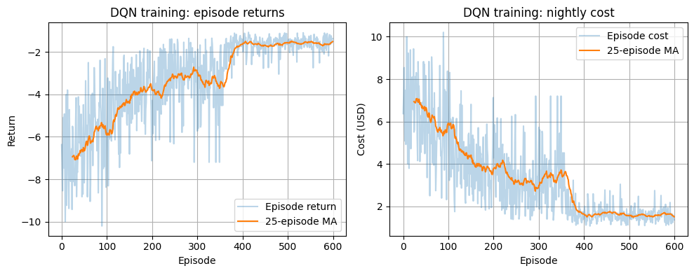

```python
def plot_training_curves(history_df: pd.DataFrame, window: int = 25):
    rolling_return = history_df["return"].rolling(window=window).mean()
    rolling_cost = history_df["episode_cost"].rolling(window=window).mean()

    fig, ax = plt.subplots(1, 2, figsize=(10, 4))

    ax[0].plot(history_df["episode"], history_df["return"], alpha=0.3, label="Episode return")
    ax[0].plot(history_df["episode"], rolling_return, label=f"{window}-episode MA")
    ax[0].set_xlabel("Episode")
    ax[0].set_ylabel("Return")
    ax[0].set_title("DQN training: episode returns")
    ax[0].grid(True)
    ax[0].legend()

    ax[1].plot(history_df["episode"], history_df["episode_cost"], alpha=0.3, label="Episode cost")
    ax[1].plot(history_df["episode"], rolling_cost, label=f"{window}-episode MA")
    ax[1].set_xlabel("Episode")
    ax[1].set_ylabel("Cost (USD)")
    ax[1].set_title("DQN training: nightly cost")
    ax[1].grid(True)
    ax[1].legend()

    plt.tight_layout()
    plt.show()


plot_training_curves(dqn_history)
```

## **Evaluate the trained DQN vs environment**

```python
def dqn_greedy_policy(env: SmartEvChargingEnv, obs: np.ndarray) -> int:
    # Use the trained agent in greedy (no-exploration) mode
    return dqn_agent.select_action(obs, explore=False)


eval_env = SmartEvChargingEnv(
    config=config,
    tariff_cfg=tariff_cfg,
    pv_cfg=pv_cfg,
    drive_cfg=drive_cfg,
    calendar_df=calendar_df,
    day_indices=None,
    n_action_levels=5,
    shortfall_penalty_per_kwh=0.6,
    seed=SEED + 123,
)

dqn_results = evaluate_policy(eval_env, dqn_greedy_policy, n_episodes=50)
print(dqn_results.head())

print("\nDQN summary:")
print(dqn_results[["episode_cost", "final_soc"]].describe())
print("\nShortfall rate:", dqn_results["final_soc"].lt(config.soc_target).mean())
```

```
   episode       date  day_index  required_kwh  final_soc  episode_cost
0        0 2024-04-15        105     15.844705       0.94      1.740061
1        1 2024-07-03        184      5.849874       0.91      1.107565
2        2 2024-05-08        128     12.975550       0.91      1.367660
3        3 2024-10-30        303     23.513668       0.91      1.323246
4        4 2024-01-19         18     17.481126       0.88      2.161864

DQN summary:
       episode_cost  final_soc
count     50.000000  50.000000
mean       1.510181   0.915400
std        0.298235   0.020723
min        1.107565   0.880000
25%        1.292107   0.910000
50%        1.369132   0.910000
75%        1.711281   0.940000
max        2.207892   0.970000

Shortfall rate: 0.14
```

# 9.0 Risk-aware deep RL via CVaR-shaped DQN

# 9.1 CVaR-shaped agent and empirical tail estimation

```python
class CvarDqnAgent(DqnAgent):
    """
    DQN agent with simple CVaR-inspired episodic reward shaping.

    Episodes whose total cost lies above an empirical VaR_alpha threshold
    receive an additional negative penalty on every transition reward.
    """

    def __init__(
        self,
        obs_dim: int,
        n_actions: int,
        device: torch.device,
        gamma: float = 0.99,
        lr: float = 1e-3,
        epsilon_start: float = 1.0,
        epsilon_end: float = 0.05,
        epsilon_decay_episodes: int = 400,
        replay_capacity: int = 50_000,
        batch_size: int = 64,
        target_update_interval: int = 50,
        cvar_alpha: float = 0.10,
        cvar_lambda: float = 1.0,
        min_episodes_for_cvar: int = 40,
    ):
        super().__init__(
            obs_dim=obs_dim,
            n_actions=n_actions,
            device=device,
            gamma=gamma,
            lr=lr,
            epsilon_start=epsilon_start,
            epsilon_end=epsilon_end,
            epsilon_decay_episodes=epsilon_decay_episodes,
            replay_capacity=replay_capacity,
            batch_size=batch_size,
            target_update_interval=target_update_interval,
        )
        self.cvar_alpha = cvar_alpha
        self.cvar_lambda = cvar_lambda
        self.min_episodes_for_cvar = min_episodes_for_cvar

        self.episode_costs: list[float] = []
        self.var_alpha: float | None = None
        self.cvar_alpha_est: float | None = None

    def _update_cvar_estimate(self):
        """
        Update empirical VaR and CVaR estimates from stored episode costs.
        """
        if len(self.episode_costs) < self.min_episodes_for_cvar:
            return

        costs = np.sort(np.array(self.episode_costs, dtype=float))
        # high-cost tail: VaR at (1 - alpha) quantile
        q = 1.0 - self.cvar_alpha
        idx = int(np.ceil(q * len(costs))) - 1
        idx = int(np.clip(idx, 0, len(costs) - 1))

        self.var_alpha = float(costs[idx])
        self.cvar_alpha_est = float(costs[idx:].mean())

    def store_episode(self, transitions, episode_cost: float):
        """
        Apply CVaR shaping and store transitions from a single episode.

        Parameters
        ----------
        transitions : list of (obs, action, reward, next_obs, done)
            Raw transitions collected during the episode.
        episode_cost : float
            Total cost of the episode, including shortfall penalties.
        """
        # Decide whether this episode lies in the high-cost tail
        penalty_flag = 0.0
        if self.var_alpha is not None and episode_cost >= self.var_alpha:
            penalty_flag = 1.0

        # Shape each reward and push into replay buffer
        for (obs, action, reward, next_obs, done) in transitions:
            r_shaped = reward - self.cvar_lambda * penalty_flag
            self.replay.add(obs, action, r_shaped, next_obs, done)

        # Update empirical distribution of episode costs
        self.episode_costs.append(float(episode_cost))
        self._update_cvar_estimate()
```

# 9.2 Training loop and risk diagnostics

Adapts the DQN training loop to the CVaR-shaped agent. In addition to the usual return and cost statistics, the code logs the evolving VaR and CVaR estimates as functions of the training episode. These diagnostics make it possible to observe whether risk shaping is successfully lowering the empirical tail of the cost distribution as learning progresses.

```python
def train_cvar_dqn_on_ev_env(
    n_episodes: int = 600,
    gamma: float = 0.99,
    lr: float = 1e-3,
    epsilon_start: float = 1.0,
    epsilon_end: float = 0.05,
    epsilon_decay_episodes: int = 400,
    batch_size: int = 64,
    replay_capacity: int = 50_000,
    target_update_interval: int = 50,
    cvar_alpha: float = 0.10,
    cvar_lambda: float = 1.0,
    min_episodes_for_cvar: int = 40,
) -> tuple[CvarDqnAgent, pd.DataFrame]:
    """
    Train a CVaR-shaped DQN agent on the SmartEvChargingEnv.

    Returns the trained agent and a DataFrame of per-episode statistics.
    """
    train_env = SmartEvChargingEnv(
        config=config,
        tariff_cfg=tariff_cfg,
        pv_cfg=pv_cfg,
        drive_cfg=drive_cfg,
        calendar_df=calendar_df,
        day_indices=None,
        n_action_levels=5,
        shortfall_penalty_per_kwh=0.6,
        seed=SEED + 1,
    )

    obs_dim = train_env.observation_space.shape[0]
    n_actions = train_env.action_space.n

    agent = CvarDqnAgent(
        obs_dim=obs_dim,
        n_actions=n_actions,
        device=device,
        gamma=gamma,
        lr=lr,
        epsilon_start=epsilon_start,
        epsilon_end=epsilon_end,
        epsilon_decay_episodes=epsilon_decay_episodes,
        replay_capacity=replay_capacity,
        batch_size=batch_size,
        target_update_interval=target_update_interval,
        cvar_alpha=cvar_alpha,
        cvar_lambda=cvar_lambda,
        min_episodes_for_cvar=min_episodes_for_cvar,
    )

    episode_records = []
    global_step = 0

    for ep in range(n_episodes):
        obs, info = train_env.reset()
        done = False
        agent.episode_count = ep

        ep_transitions = []
        ep_return = 0.0
        ep_cost = 0.0
        ep_shortfall_flag = 0

        while not done:
            action = agent.select_action(obs, explore=True)
            next_obs, reward, terminated, truncated, info = train_env.step(action)
            done = terminated or truncated

            ep_transitions.append((obs, action, reward, next_obs, done))
            obs = next_obs
            ep_return += reward
            ep_cost = info["episode_cost"]
            global_step += 1

            # Perform a gradient step whenever enough data exist
            train_info = agent.train_step()
            if global_step % agent.target_update_interval == 0:
                agent.update_target_network()

        # Determine if there was a shortfall
        final_soc = info["soc"]
        required_soc_from_trip = info["required_kwh"] / config.battery_capacity_kwh
        required_soc = max(config.soc_target, required_soc_from_trip)
        required_soc = np.clip(required_soc, config.soc_min, config.soc_max)
        if final_soc + 1e-6 < required_soc:
            ep_shortfall_flag = 1

        # Store episode with CVaR shaping
        agent.store_episode(ep_transitions, ep_cost)

        episode_records.append(
            {
                "episode": ep,
                "return": ep_return,
                "episode_cost": ep_cost,
                "final_soc": final_soc,
                "required_kwh": info["required_kwh"],
                "shortfall": ep_shortfall_flag,
                "var_alpha": agent.var_alpha,
                "cvar_alpha": agent.cvar_alpha_est,
            }
        )

        if (ep + 1) % 50 == 0:
            print(
                f"[CVaR-DQN] Episode {ep + 1}/{n_episodes} "
                f"return={ep_return:.2f} cost=${ep_cost:.2f} "
                f"final_soc={final_soc:.2f} shortfall={ep_shortfall_flag} "
                f"VaR={agent.var_alpha if agent.var_alpha is not None else float('nan'):.2f} "
                f"CVaR={agent.cvar_alpha_est if agent.cvar_alpha_est is not None else float('nan'):.2f}"
            )

    history_df = pd.DataFrame(episode_records)
    return agent, history_df
```

## **Train CVaR-DQN and Curves**

The following cell trains a CVaR-shaped DQN agent using the same hyperparameters as the standard DQN, but with a tail level of $(\alpha = 0.10)$ and a penalty weight $(\lambda = 1.0)$. The resulting learning curves provide a first indication of how the risk-sensitive shaping affects cost and returns.

```python
cvar_dqn_agent, cvar_dqn_history = train_cvar_dqn_on_ev_env(
    n_episodes=600,
    gamma=0.99,
    lr=1e-3,
    epsilon_start=1.0,
    epsilon_end=0.05,
    epsilon_decay_episodes=400,
    batch_size=64,
    replay_capacity=20_000,
    target_update_interval=50,
    cvar_alpha=0.10,
    cvar_lambda=1.0,
    min_episodes_for_cvar=40,
)

cvar_dqn_history.head()
```

```
[CVaR-DQN] Episode 50/600 return=-3.15 cost=$3.15 final_soc=1.00 shortfall=0 VaR=8.39 CVaR=8.88
[CVaR-DQN] Episode 100/600 return=-3.89 cost=$3.89 final_soc=1.00 shortfall=0 VaR=8.02 CVaR=8.71
[CVaR-DQN] Episode 150/600 return=-2.75 cost=$2.75 final_soc=1.00 shortfall=0 VaR=7.81 CVaR=8.57
[CVaR-DQN] Episode 200/600 return=-4.87 cost=$4.87 final_soc=1.00 shortfall=0 VaR=7.29 CVaR=8.30
[CVaR-DQN] Episode 250/600 return=-2.33 cost=$2.33 final_soc=1.00 shortfall=0 VaR=7.19 CVaR=8.14
[CVaR-DQN] Episode 300/600 return=-2.25 cost=$2.25 final_soc=0.91 shortfall=0 VaR=7.07 CVaR=7.98
[CVaR-DQN] Episode 350/600 return=-3.56 cost=$3.56 final_soc=0.85 shortfall=1 VaR=6.74 CVaR=7.83
[CVaR-DQN] Episode 400/600 return=-1.81 cost=$1.81 final_soc=0.97 shortfall=0 VaR=6.62 CVaR=7.70
[CVaR-DQN] Episode 450/600 return=-1.52 cost=$1.52 final_soc=0.97 shortfall=0 VaR=6.51 CVaR=7.58
[CVaR-DQN] Episode 500/600 return=-2.04 cost=$2.04 final_soc=1.00 shortfall=0 VaR=6.43 CVaR=7.47
[CVaR-DQN] Episode 550/600 return=-2.04 cost=$2.04 final_soc=1.00 shortfall=0 VaR=6.33 CVaR=7.37
[CVaR-DQN] Episode 600/600 return=-1.47 cost=$1.47 final_soc=0.94 shortfall=0 VaR=6.26 CVaR=7.28
```

|  | episode | return | episode_cost | final_soc | required_kwh | shortfall | var_alpha | cvar_alpha |
| --- | --- | --- | --- | --- | --- | --- | --- | --- |
| 0 | 0 | -6.864101 | 6.864101 | 1.0 | 17.353051 | 0 | NaN | NaN |
| 1 | 1 | -7.187404 | 7.187404 | 1.0 | 4.170643 | 0 | NaN | NaN |
| 2 | 2 | -5.376122 | 5.376122 | 1.0 | 17.476094 | 0 | NaN | NaN |
| 3 | 3 | -7.311048 | 7.311048 | 1.0 | 10.073050 | 0 | NaN | NaN |
| 4 | 4 | -6.621588 | 6.621588 | 1.0 | 5.607773 | 0 | NaN | NaN |

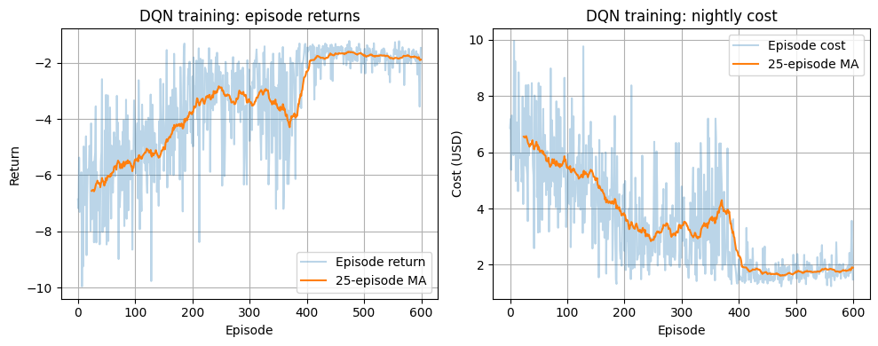

```python
plot_training_curves(cvar_dqn_history)
```

# 9.3 Evaluation of CVaR-DQN and comparison with DQN

Evaluates the greedy policy induced by the CVaR-shaped agent using the same protocol as for DQN. The resulting distribution of nightly costs and shortfall rate is compared against the risk-neutral DQN. Typically, the CVaR-shaped agent exhibits slightly higher mean cost but improved high-percentile costs and a lower or even zero shortfall rate, illustrating a clear cost–risk trade-off.

```python
def cvar_dqn_greedy_policy(env: SmartEvChargingEnv, obs: np.ndarray) -> int:
    return cvar_dqn_agent.select_action(obs, explore=False)


eval_env_cvar = SmartEvChargingEnv(
    config=config,
    tariff_cfg=tariff_cfg,
    pv_cfg=pv_cfg,
    drive_cfg=drive_cfg,
    calendar_df=calendar_df,
    day_indices=None,
    n_action_levels=5,
    shortfall_penalty_per_kwh=0.6,
    seed=SEED + 456,
)

cvar_results = evaluate_policy(eval_env_cvar, cvar_dqn_greedy_policy, n_episodes=50)
print(cvar_results.head())

print("\nCVaR-DQN summary:")
print(cvar_results[["episode_cost", "final_soc"]].describe())

print("\nCost percentiles (DQN vs CVaR-DQN):")
for p in [50, 75, 90, 95, 99]:
    dqn_p = np.percentile(dqn_results["episode_cost"], p)
    cvar_p = np.percentile(cvar_results["episode_cost"], p)
    print(f"p{p:>2}: DQN={dqn_p:.2f}, CVaR-DQN={cvar_p:.2f}")

print("\nShortfall rates:")
print("DQN shortfall rate:   ", dqn_results["final_soc"].lt(config.soc_target).mean())
print("CVaR-DQN shortfall rate:", cvar_results["final_soc"].lt(config.soc_target).mean())
```

```
   episode       date  day_index  required_kwh  final_soc  episode_cost
0        0 2024-12-09        343     13.332844       0.94      1.634813
1        1 2024-02-20         50     13.707262       0.94      1.564681
2        2 2024-01-11         10     12.873077       0.94      1.555455
3        3 2024-06-03        154      9.117785       0.97      1.524821
4        4 2024-09-23        266     14.338122       0.97      1.761953

CVaR-DQN summary:
       episode_cost  final_soc
count     50.000000  50.000000
mean       1.568459   0.956200
std        0.127076   0.023638
min        1.106102   0.910000
25%        1.520315   0.940000
50%        1.576405   0.970000
75%        1.635471   0.970000
max        1.834746   1.000000

Cost percentiles (DQN vs CVaR-DQN):
p50: DQN=1.37, CVaR-DQN=1.58
p75: DQN=1.71, CVaR-DQN=1.64
p90: DQN=1.91, CVaR-DQN=1.68
p95: DQN=2.16, CVaR-DQN=1.76
p99: DQN=2.19, CVaR-DQN=1.80

Shortfall rates:
DQN shortfall rate:    0.14
CVaR-DQN shortfall rate: 0.0
```

# 10.0 Distributional RL: Quantile Regression DQN (QR-DQN)

# 10.1 Quantile value network and QR-DQN agent

Defines a quantile Q-network that outputs a fixed set of quantile values for each action instead of a single scalar Q-value. A `QrDqnAgent` wraps this network and implements the quantile regression Huber loss over sampled transitions. Targets are constructed by applying the Bellman operator to the distribution at the next state and then aligning predicted and target quantiles according to the chosen quantile levels. This yields a distributional analogue of DQN that can model the full distribution of discounted returns.

```python
class QuantileQNetwork(nn.Module):
    """
    Neural network that outputs a set of quantile values for each action.

    Given a state vector s, the forward pass returns a tensor of shape
    [batch_size, n_actions, n_quantiles].
    """

    def __init__(self, obs_dim: int, n_actions: int, n_quantiles: int = 51, hidden_sizes=(64, 64)):
        super().__init__()
        self.n_actions = n_actions
        self.n_quantiles = n_quantiles

        layers = []
        input_dim = obs_dim
        for h in hidden_sizes:
            layers.append(nn.Linear(input_dim, h))
            layers.append(nn.ReLU())
            input_dim = h
        layers.append(nn.Linear(input_dim, n_actions * n_quantiles))
        self.net = nn.Sequential(*layers)

    def forward(self, x: torch.Tensor) -> torch.Tensor:
        # x: [B, obs_dim] -> [B, n_actions, n_quantiles]
        out = self.net(x)
        out = out.view(x.shape[0], self.n_actions, self.n_quantiles)
        return out


class QrDqnAgent:
    """
    Quantile Regression DQN (QR-DQN) agent.

    Uses a distributional critic with N quantiles per action and quantile
    regression Huber loss for training. Action selection is based on the
    mean value across quantiles.
    """

    def __init__(
        self,
        obs_dim: int,
        n_actions: int,
        device: torch.device,
        n_quantiles: int = 51,
        gamma: float = 0.99,
        lr: float = 1e-3,
        epsilon_start: float = 1.0,
        epsilon_end: float = 0.05,
        epsilon_decay_episodes: int = 400,
        replay_capacity: int = 50_000,
        batch_size: int = 64,
        target_update_interval: int = 50,
    ):
        self.device = device
        self.gamma = gamma
        self.batch_size = batch_size
        self.target_update_interval = target_update_interval
        self.n_actions = n_actions
        self.n_quantiles = n_quantiles

        self.online_net = QuantileQNetwork(obs_dim, n_actions, n_quantiles).to(device)
        self.target_net = QuantileQNetwork(obs_dim, n_actions, n_quantiles).to(device)
        self.target_net.load_state_dict(self.online_net.state_dict())

        self.optimizer = optim.Adam(self.online_net.parameters(), lr=lr)
        self.replay = ReplayBuffer(replay_capacity, obs_dim)

        # Fixed quantile fractions tau_i in (0, 1)
        # Shape: [1, 1, N] for broadcasting in loss
        taus = (torch.arange(n_quantiles, dtype=torch.float32) + 0.5) / n_quantiles
        self.taus = taus.view(1, 1, n_quantiles).to(device)

        # Epsilon schedule
        self.epsilon_start = epsilon_start
        self.epsilon_end = epsilon_end
        self.epsilon_decay_episodes = max(1, epsilon_decay_episodes)
        self.episode_count = 0

    def epsilon(self) -> float:
        frac = min(1.0, self.episode_count / self.epsilon_decay_episodes)
        return self.epsilon_start + frac * (self.epsilon_end - self.epsilon_start)

    def select_action(self, obs: np.ndarray, explore: bool = True) -> int:
        if explore and np.random.rand() < self.epsilon():
            return np.random.randint(self.n_actions)

        obs_t = torch.tensor(obs, dtype=torch.float32, device=self.device).unsqueeze(0)
        with torch.no_grad():
            quantiles = self.online_net(obs_t)  # [1, n_actions, n_quantiles]
            q_means = quantiles.mean(dim=2)     # [1, n_actions]
        action = int(q_means.argmax(dim=1).item())
        return action

    def store_transition(self, obs, action, reward, next_obs, done):
        self.replay.add(obs, action, reward, next_obs, done)

    def train_step(self):
        if len(self.replay) < self.batch_size:
            return {}

        batch = self.replay.sample(self.batch_size)
        obs = torch.tensor(batch["obs"], dtype=torch.float32, device=self.device)
        next_obs = torch.tensor(batch["next_obs"], dtype=torch.float32, device=self.device)
        acts = torch.tensor(batch["acts"], dtype=torch.long, device=self.device)
        rews = torch.tensor(batch["rews"], dtype=torch.float32, device=self.device)
        dones = torch.tensor(batch["dones"], dtype=torch.float32, device=self.device)

        # Current quantiles for chosen actions: [B, 1, N]
        all_quantiles = self.online_net(obs)  # [B, A, N]
        acts_expanded = acts.view(-1, 1, 1).expand(-1, 1, self.n_quantiles)
        chosen_quantiles = all_quantiles.gather(1, acts_expanded)  # [B, 1, N]

        # Target quantiles using double-DQN style action selection
        with torch.no_grad():
            next_all_online = self.online_net(next_obs)  # [B, A, N]
            next_q_means = next_all_online.mean(dim=2)   # [B, A]
            next_actions = next_q_means.argmax(dim=1)    # [B]

            next_all_target = self.target_net(next_obs)  # [B, A, N]
            next_actions_expanded = next_actions.view(-1, 1, 1).expand(-1, 1, self.n_quantiles)
            next_quantiles = next_all_target.gather(1, next_actions_expanded).squeeze(1)  # [B, N]

            # Bellman target for each quantile
            # rews: [B], dones: [B]
            rews_exp = rews.view(-1, 1)
            dones_exp = dones.view(-1, 1)
            target_quantiles = rews_exp + self.gamma * (1.0 - dones_exp) * next_quantiles  # [B, N]

        # Quantile regression Huber loss
        # chosen_quantiles: [B, 1, N]
        # target_quantiles: [B, N] -> [B, N, 1]
        target_quantiles = target_quantiles.view(-1, self.n_quantiles, 1)
        chosen_quantiles = chosen_quantiles  # [B, 1, N]

        # TD error delta_ij = target_j - prediction_i
        td_error = target_quantiles - chosen_quantiles  # [B, N, N]
        huber_kappa = 1.0

        abs_error = torch.abs(td_error)
        huber_loss = torch.where(
            abs_error <= huber_kappa,
            0.5 * td_error ** 2,
            huber_kappa * (abs_error - 0.5 * huber_kappa),
        )

        # Compute quantile regression weights |tau - 1_{delta<0}|
        # taus: [1, 1, N]; we need shape [B, N, N]
        taus = self.taus  # [1,1,N]
        indicator = (td_error.detach() < 0.0).float()
        quantile_weights = torch.abs(taus - indicator)  # broadcasts to [B, N, N]

        loss = (quantile_weights * huber_loss).mean()

        self.optimizer.zero_grad()
        loss.backward()
        self.optimizer.step()

        return {"loss": float(loss.item())}

    def update_target_network(self):
        self.target_net.load_state_dict(self.online_net.state_dict())
```

# 10.2 QR-DQN training on the EV environment

Trains the QR-DQN agent on the EV environment using a loop analogous to the DQN case. Transitions are collected in a replay buffer, and minibatch updates minimise the quantile regression loss between predicted and target return distributions. The code records per-episode returns and costs, and prints summary statistics periodically to track learning progress.

```python
def train_qr_dqn_on_ev_env(
    n_episodes: int = 600,
    n_quantiles: int = 51,
    gamma: float = 0.99,
    lr: float = 1e-3,
    epsilon_start: float = 1.0,
    epsilon_end: float = 0.05,
    epsilon_decay_episodes: int = 400,
    batch_size: int = 64,
    replay_capacity: int = 50_000,
    target_update_interval: int = 50,
) -> tuple[QrDqnAgent, pd.DataFrame]:
    """
    Train a QR-DQN agent on the SmartEvChargingEnv.

    Returns the trained agent and a DataFrame with per-episode statistics.
    """
    train_env = SmartEvChargingEnv(
        config=config,
        tariff_cfg=tariff_cfg,
        pv_cfg=pv_cfg,
        drive_cfg=drive_cfg,
        calendar_df=calendar_df,
        day_indices=None,
        n_action_levels=5,
        shortfall_penalty_per_kwh=0.6,
        seed=SEED + 2,
    )

    obs_dim = train_env.observation_space.shape[0]
    n_actions = train_env.action_space.n

    agent = QrDqnAgent(
        obs_dim=obs_dim,
        n_actions=n_actions,
        device=device,
        n_quantiles=n_quantiles,
        gamma=gamma,
        lr=lr,
        epsilon_start=epsilon_start,
        epsilon_end=epsilon_end,
        epsilon_decay_episodes=epsilon_decay_episodes,
        replay_capacity=replay_capacity,
        batch_size=batch_size,
        target_update_interval=target_update_interval,
    )

    episode_records = []
    global_step = 0

    for ep in range(n_episodes):
        obs, info = train_env.reset()
        done = False
        agent.episode_count = ep

        ep_return = 0.0
        ep_cost = 0.0
        ep_shortfall_flag = 0

        while not done:
            action = agent.select_action(obs, explore=True)
            next_obs, reward, terminated, truncated, info = train_env.step(action)
            done = terminated or truncated

            agent.store_transition(obs, action, reward, next_obs, done)
            train_info = agent.train_step()
            obs = next_obs
            ep_return += reward
            ep_cost = info["episode_cost"]
            global_step += 1

            if global_step % agent.target_update_interval == 0:
                agent.update_target_network()

        # Shortfall indicator
        final_soc = info["soc"]
        required_soc_from_trip = info["required_kwh"] / config.battery_capacity_kwh
        required_soc = max(config.soc_target, required_soc_from_trip)
        required_soc = np.clip(required_soc, config.soc_min, config.soc_max)
        if final_soc + 1e-6 < required_soc:
            ep_shortfall_flag = 1

        episode_records.append(
            {
                "episode": ep,
                "return": ep_return,
                "episode_cost": ep_cost,
                "final_soc": final_soc,
                "required_kwh": info["required_kwh"],
                "shortfall": ep_shortfall_flag,
            }
        )

        if (ep + 1) % 50 == 0:
            print(
                f"[QR-DQN] Episode {ep + 1}/{n_episodes} "
                f"return={ep_return:.2f} cost=${ep_cost:.2f} "
                f"final_soc={final_soc:.2f} shortfall={ep_shortfall_flag}"
            )

    history_df = pd.DataFrame(episode_records)
    return agent, history_df
```

# **Train QR-DQN and plot curves**

The next cell trains the QR-DQN agent and visualizes its learning curves for comparison with the standard and CVaR-shaped DQN agents.

```python
qr_dqn_agent, qr_dqn_history = train_qr_dqn_on_ev_env(
    n_episodes=600,
    n_quantiles=51,
    gamma=0.99,
    lr=1e-3,
    epsilon_start=1.0,
    epsilon_end=0.05,
    epsilon_decay_episodes=400,
    batch_size=64,
    replay_capacity=20_000,
    target_update_interval=50,
)

qr_dqn_history.head()
```

```
[QR-DQN] Episode 50/600 return=-6.23 cost=$6.23 final_soc=1.00 shortfall=0
[QR-DQN] Episode 100/600 return=-4.05 cost=$4.05 final_soc=1.00 shortfall=0
[QR-DQN] Episode 150/600 return=-3.59 cost=$3.59 final_soc=1.00 shortfall=0
[QR-DQN] Episode 200/600 return=-1.51 cost=$1.51 final_soc=0.91 shortfall=0
[QR-DQN] Episode 250/600 return=-3.40 cost=$3.40 final_soc=1.00 shortfall=0
[QR-DQN] Episode 300/600 return=-4.44 cost=$4.44 final_soc=1.00 shortfall=0
[QR-DQN] Episode 350/600 return=-4.53 cost=$4.53 final_soc=0.79 shortfall=1
[QR-DQN] Episode 400/600 return=-3.48 cost=$3.48 final_soc=0.82 shortfall=1
[QR-DQN] Episode 450/600 return=-1.37 cost=$1.37 final_soc=0.91 shortfall=0
[QR-DQN] Episode 500/600 return=-1.43 cost=$1.43 final_soc=0.94 shortfall=0
[QR-DQN] Episode 550/600 return=-1.56 cost=$1.56 final_soc=0.97 shortfall=0
[QR-DQN] Episode 600/600 return=-1.67 cost=$1.67 final_soc=0.97 shortfall=0
```

|  | episode | return | episode_cost | final_soc | required_kwh | shortfall |
| --- | --- | --- | --- | --- | --- | --- |
| 0 | 0 | -7.650538 | 7.650538 | 1.0 | 9.345788 | 0 |
| 1 | 1 | -7.527535 | 7.527535 | 1.0 | 3.506351 | 0 |
| 2 | 2 | -6.203396 | 6.203396 | 1.0 | 40.000000 | 0 |
| 3 | 3 | -9.174784 | 9.174784 | 1.0 | 10.699747 | 0 |
| 4 | 4 | -6.095775 | 6.095775 | 1.0 | 19.545362 | 0 |

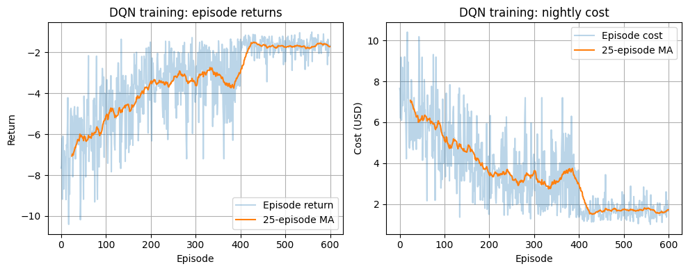

```python
plot_training_curves(qr_dqn_history)
```

# 10.3 Evaluation and joint comparison of DQN, CVaR-DQN, and QR-DQN

```python
def qr_dqn_greedy_policy(env: SmartEvChargingEnv, obs: np.ndarray) -> int:
    return qr_dqn_agent.select_action(obs, explore=False)


eval_env_qr = SmartEvChargingEnv(
    config=config,
    tariff_cfg=tariff_cfg,
    pv_cfg=pv_cfg,
    drive_cfg=drive_cfg,
    calendar_df=calendar_df,
    day_indices=None,
    n_action_levels=5,
    shortfall_penalty_per_kwh=0.6,
    seed=SEED + 789,
)

qr_results = evaluate_policy(eval_env_qr, qr_dqn_greedy_policy, n_episodes=50)
print(qr_results.head())

print("\nQR-DQN summary:")
print(qr_results[["episode_cost", "final_soc"]].describe())

print("\nCost percentiles (DQN vs CVaR-DQN vs QR-DQN):")
for p in [50, 75, 90, 95, 99]:
    dqn_p = np.percentile(dqn_results["episode_cost"], p)
    cvar_p = np.percentile(cvar_results["episode_cost"], p)
    qr_p = np.percentile(qr_results["episode_cost"], p)
    print(f"p{p:>2}: DQN={dqn_p:.2f}, CVaR-DQN={cvar_p:.2f}, QR-DQN={qr_p:.2f}")

print("\nShortfall rates:")
print("DQN shortfall rate:      ", dqn_results["final_soc"].lt(config.soc_target).mean())
print("CVaR-DQN shortfall rate: ", cvar_results["final_soc"].lt(config.soc_target).mean())
print("QR-DQN shortfall rate:   ", qr_results["final_soc"].lt(config.soc_target).mean())
```

```
   episode       date  day_index  required_kwh  final_soc  episode_cost
0        0 2024-03-18         77      8.173151       0.97      1.671276
1        1 2024-12-19        353     16.509790       0.97      1.802257
2        2 2024-05-16        136     14.089123       0.97      1.683806
3        3 2024-05-17        137     12.488093       0.97      1.621246
4        4 2024-03-11         70     16.461911       0.94      1.536890

QR-DQN summary:
       episode_cost  final_soc
count     50.000000  50.000000
mean       1.607333   0.959800
std        0.183570   0.027515
min        1.039312   0.880000
25%        1.518503   0.940000
50%        1.624953   0.970000
75%        1.735490   0.970000
max        1.876574   1.000000

Cost percentiles (DQN vs CVaR-DQN vs QR-DQN):
p50: DQN=1.37, CVaR-DQN=1.58, QR-DQN=1.62
p75: DQN=1.71, CVaR-DQN=1.64, QR-DQN=1.74
p90: DQN=1.91, CVaR-DQN=1.68, QR-DQN=1.80
p95: DQN=2.16, CVaR-DQN=1.76, QR-DQN=1.84
p99: DQN=2.19, CVaR-DQN=1.80, QR-DQN=1.87

Shortfall rates:
DQN shortfall rate:       0.14
CVaR-DQN shortfall rate:  0.0
QR-DQN shortfall rate:    0.04
```

# 11.0 Solar-aware baseline and summary comparison

The Greedy-TOU heuristic in Section 7 exploits time-of-use prices but ignores rooftop PV. As a final baseline, it is useful to add a simple solar-aware strategy that preferentially charges during hours with high PV output, while still being sensitive to prices.

The solar-aware policy used here plans the night by ranking hours according to an approximate “effective grid cost”: $$ \text{effective_cost}_t = p_t \cdot \max\left(0, 1 - \frac{\text{PV}_t}{P_{\max}}\right), $$ where $p_t$ is the price and $P_{\max}$ is the maximum charging power. Hours with enough PV to cover most of the charging power have very low effective cost, so they are chosen first. The policy then charges at maximum power in the cheapest effective-cost slots until the required energy level is reached.

## **Solar-aware policy and evaluation**

```python
def solar_aware_policy(env: SmartEvChargingEnv, obs: np.ndarray) -> int:

    cfg = env.config
    capacity = cfg.battery_capacity_kwh
    delta_t = cfg.delta_t_hours
    max_power = cfg.max_charge_kw
    max_energy_per_step = max_power * delta_t

    # Required SoC level based on mobility and target
    required_soc_from_trip = env.required_kwh / capacity
    required_soc = max(cfg.soc_target, required_soc_from_trip)
    required_soc = np.clip(required_soc, cfg.soc_min, cfg.soc_max)

    # Energy deficit at the beginning of the night
    current_energy = env.soc * capacity
    target_energy = required_soc * capacity
    energy_deficit = max(0.0, target_energy - current_energy)

    if max_energy_per_step <= 0.0 or energy_deficit <= 0.0:
        # No need to charge
        charge_slots = set()
    else:
        # Effective grid cost per kWh if charging at max power:
        # grid share = max(0, 1 - PV/max_power)
        prices = env.price_profile
        pv_kw = env.pv_profile
        grid_share = np.maximum(0.0, 1.0 - pv_kw / max_power)
        effective_cost = prices * grid_share  # lower is better

        n_slots_needed = int(math.ceil(energy_deficit / max_energy_per_step))
        n_slots_needed = min(n_slots_needed, cfg.steps_per_episode)

        # Indices of hours with lowest effective grid cost
        cheapest_indices = np.argsort(effective_cost)[:n_slots_needed]
        charge_slots = set(int(i) for i in cheapest_indices)

    # Control: charge at max power in selected hours, otherwise do nothing
    if env.t_index in charge_slots:
        return env.action_space.n - 1
    else:
        return 0


# Evaluate solar-aware baseline
solar_env = SmartEvChargingEnv(
    config=config,
    tariff_cfg=tariff_cfg,
    pv_cfg=pv_cfg,
    drive_cfg=drive_cfg,
    calendar_df=calendar_df,
    day_indices=None,
    n_action_levels=5,
    shortfall_penalty_per_kwh=0.6,
    seed=SEED + 321,
)

solar_results = evaluate_policy(solar_env, solar_aware_policy, n_episodes=50)
print(solar_results.head())

print("\nSolar-aware summary:")
print(solar_results[["episode_cost", "final_soc"]].describe())
print("\nShortfall rate:", solar_results["final_soc"].lt(config.soc_target).mean())
```

```
   episode       date  day_index  required_kwh  final_soc  episode_cost
0        0 2024-11-17        321      6.862948       0.82      3.595163
1        1 2024-03-05         64     12.072851       0.94      1.592113
2        2 2024-03-24         83     24.332545       0.82      3.577061
3        3 2024-10-23        296     15.384880       0.82      3.656893
4        4 2024-11-10        314     13.841310       0.82      3.580273

Solar-aware summary:
       episode_cost  final_soc
count     50.000000  50.000000
mean       2.356933   0.894400
std        1.018121   0.058838
min        1.368926   0.820000
25%        1.564759   0.820000
50%        1.647136   0.940000
75%        3.630420   0.940000
max        3.717906   0.940000

Shortfall rate: 0.38
```

## **Compact comparison table for all methods**

```python
def summarize_results(name: str, df: pd.DataFrame) -> dict:
    return {
        "policy": name,
        "mean_cost": df["episode_cost"].mean(),
        "std_cost": df["episode_cost"].std(),
        "p50_cost": np.percentile(df["episode_cost"], 50),
        "p90_cost": np.percentile(df["episode_cost"], 90),
        "p95_cost": np.percentile(df["episode_cost"], 95),
        "shortfall_rate": df["final_soc"].lt(config.soc_target).mean(),
    }

summary_rows = [
    summarize_results("Greedy-TOU", greedy_results),
    summarize_results("Solar-aware", solar_results),
    summarize_results("DQN", dqn_results),
    summarize_results("CVaR-DQN", cvar_results),
    summarize_results("QR-DQN", qr_results),
]

summary_df = pd.DataFrame(summary_rows)
print(summary_df)
```

```
        policy  mean_cost  std_cost  p50_cost  p90_cost  p95_cost  \
0   Greedy-TOU   2.732405  1.064565  3.588601  3.713429  3.719060
1  Solar-aware   2.356933  1.018121  1.647136  3.660899  3.683420
2          DQN   1.510181  0.298235  1.369132  1.913168  2.156667
3     CVaR-DQN   1.568459  0.127076  1.576405  1.679521  1.762879
4       QR-DQN   1.607333  0.183570  1.624953  1.797099  1.838415

   shortfall_rate
0            0.56
1            0.38
2            0.14
3            0.00
4            0.04
```

# 12.0 Optimization oracle baseline

# 12.1 Linear-programming formulation and optimal power schedule

```python
import math
import pulp

def compute_oracle_schedule_for_env(env: SmartEvChargingEnv) -> np.ndarray:
    """
    Solve a per-night optimisation problem with perfect foresight.

    The oracle chooses continuous charging powers (grid + PV) in each time step
    to minimise total grid energy cost plus a penalty on final shortfall.

    """
    cfg = env.config
    T = cfg.steps_per_episode
    delta_t = cfg.delta_t_hours
    max_power = cfg.max_charge_kw
    capacity = cfg.battery_capacity_kwh
    soc_min = cfg.soc_min
    soc_max = cfg.soc_max

    prices = env.price_profile          # shape [T]
    pv_kw = env.pv_profile              # shape [T]
    required_kwh = env.required_kwh
    penalty_per_kwh = env.shortfall_penalty_per_kwh

    # Initial SoC (fraction)
    soc0 = env.soc

    # Set up LP
    prob = pulp.LpProblem("ev_oracle", pulp.LpMinimize)

    # Decision variables
    p_grid = pulp.LpVariable.dicts("p_grid", range(T), lowBound=0.0)
    p_pv = pulp.LpVariable.dicts("p_pv", range(T), lowBound=0.0)
    soc = pulp.LpVariable.dicts("soc", range(T + 1), lowBound=soc_min, upBound=soc_max)
    shortfall = pulp.LpVariable("shortfall", lowBound=0.0)

    # Initial SoC
    prob += soc[0] == soc0

    # SoC dynamics and power limits
    for t in range(T):
        # PV cannot exceed available PV and total power cannot exceed charger rating
        prob += p_pv[t] <= pv_kw[t]
        prob += p_grid[t] + p_pv[t] <= max_power

        # SoC_{t+1} = SoC_t + (grid + PV energy) / capacity
        energy_added_kwh = (p_grid[t] + p_pv[t]) * delta_t
        prob += soc[t + 1] == soc[t] + energy_added_kwh / capacity

    # Effective required SoC (same logic as in the environment)
    required_soc_from_trip = required_kwh / capacity
    required_soc = max(cfg.soc_target, required_soc_from_trip)
    required_soc = float(np.clip(required_soc, soc_min, soc_max))

    # Final SoC plus slack must cover the requirement
    prob += soc[T] * capacity + shortfall >= required_soc * capacity

    # Objective: sum of grid energy cost + shortfall penalty
    cost_terms = [prices[t] * p_grid[t] * delta_t for t in range(T)]
    prob += pulp.lpSum(cost_terms) + penalty_per_kwh * shortfall

    # Solve LP
    prob.solve(pulp.PULP_CBC_CMD(msg=False))

    # Extract optimal total charging power per time step
    p_total = np.array(
        [p_grid[t].value() + p_pv[t].value() for t in range(T)],
        dtype=np.float32,
    )
    return p_total
```

# 12.2 Projection onto discrete actions and oracle evaluation

```python
def continuous_power_to_action(env: SmartEvChargingEnv, p_kw: float) -> int:
    """
    Map a continuous charging power (kW) to the nearest discrete action.

    Assumes the action space consists of evenly spaced power levels between
    0 and max_charge_kw.
    """
    max_power = env.config.max_charge_kw
    n_levels = env.action_space.n

    if max_power <= 0 or n_levels <= 1:
        return 0

    frac = float(np.clip(p_kw / max_power, 0.0, 1.0))
    action_idx = int(round(frac * (n_levels - 1)))
    action_idx = int(np.clip(action_idx, 0, n_levels - 1))
    return action_idx


def oracle_policy(env: SmartEvChargingEnv, obs: np.ndarray) -> int:
    """
    Oracle policy that uses the pre-computed optimal schedule for the current night.

    On the first time step of each episode (t_index == 0), it solves the LP and
    stores the sequence of discrete actions in env._oracle_actions. On later
    steps, it simply returns the pre-planned action for the current time index.
    """
    # At the start of an episode, plan the whole night
    if env.t_index == 0 or not hasattr(env, "_oracle_actions"):
        p_plan = compute_oracle_schedule_for_env(env)
        actions = [continuous_power_to_action(env, p) for p in p_plan]
        env._oracle_actions = actions

    t = env.t_index
    if 0 <= t < len(env._oracle_actions):
        return env._oracle_actions[t]
    else:
        # Safety fallback if something goes out of range
        return 0
```

# 13.0 Summary comparison across all main policies

```python
oracle_env = SmartEvChargingEnv(
    config=config,
    tariff_cfg=tariff_cfg,
    pv_cfg=pv_cfg,
    drive_cfg=drive_cfg,
    calendar_df=calendar_df,
    day_indices=None,
    n_action_levels=5,
    shortfall_penalty_per_kwh=0.6,
    seed=SEED + 999,
)

oracle_results = evaluate_policy(oracle_env, oracle_policy, n_episodes=50)
print(oracle_results.head())

print("\nOracle summary:")
print(oracle_results[["episode_cost", "final_soc"]].describe())
print("\nShortfall rate:", oracle_results["final_soc"].lt(config.soc_target).mean())
```

```
   episode       date  day_index  required_kwh  final_soc  episode_cost
0        0 2024-10-09        282     15.544530       0.88      1.846394
1        1 2024-07-04        185     14.091714       0.91      1.280492
2        2 2024-12-15        349     11.189489       0.85      2.637238
3        3 2024-06-18        169      8.040466       0.88      1.682029
4        4 2024-06-29        180      5.206819       0.88      1.642266

Oracle summary:
       episode_cost  final_soc
count     50.000000  50.000000
mean       2.210185   0.866800
std        0.514604   0.017313
min        1.218109   0.850000
25%        1.752924   0.850000
50%        1.905833   0.880000
75%        2.742386   0.880000
max        2.793337   0.910000

Shortfall rate: 0.96
```

# 13.1 Compact performance table

```python
summary_rows = [
    summarize_results("Oracle", oracle_results),
    summarize_results("Greedy-TOU", greedy_results),
    summarize_results("Solar-aware", solar_results),
    summarize_results("DQN", dqn_results),
    summarize_results("CVaR-DQN", cvar_results),
    summarize_results("QR-DQN", qr_results),
]

summary_df = pd.DataFrame(summary_rows)
print(summary_df)
```

```
        policy  mean_cost  std_cost  p50_cost  p90_cost  p95_cost  \
0       Oracle   2.210185  0.514604  1.905833  2.771836  2.785938
1   Greedy-TOU   2.732405  1.064565  3.588601  3.713429  3.719060
2  Solar-aware   2.356933  1.018121  1.647136  3.660899  3.683420
3          DQN   1.510181  0.298235  1.369132  1.913168  2.156667
4     CVaR-DQN   1.568459  0.127076  1.576405  1.679521  1.762879
5       QR-DQN   1.607333  0.183570  1.624953  1.797099  1.838415

   shortfall_rate
0            0.96
1            0.56
2            0.38
3            0.14
4            0.00
5            0.04
```

# 14.0 Tabular Q-learning on a simplified EV model

# 14.1 Toy environment with discrete states and actions

Introduces a small toy EV-charging environment `ToyEvEnv` with fully discrete state and action spaces. Time is modelled as a short horizon of 𝑇 T discrete steps, SoC is discretised into a finite number of bins between a minimum and maximum value, and the action set consists of three charging modes (no charging, medium charging, full charging). Prices follow a fixed time-of-use vector, and the reward at each step is minus the grid cost. At the terminal step, an additional penalty is applied if the final SoC is below a specified target. This compact model admits an exact tabular Q-function.

```python
class ToyEvEnv:
    """
    Simple tabular EV environment with discrete time and discretised SoC.

    - Horizon: T discrete steps (e.g., 8).
    - SoC discretised into N levels between soc_min and soc_max.
    - Actions: 0 = no charge, 1 = medium charge, 2 = full charge.
    - Fixed TOU price profile, no PV.
    - Reward: negative grid cost per step, and a terminal penalty if SoC is
      below a required target at the end.

    This is a toy environment used only for tabular Q-learning.
    """

    def __init__(
        self,
        T: int = 8,
        n_soc_bins: int = 11,
        soc_min: float = 0.2,
        soc_max: float = 1.0,
        soc_start: float = 0.4,
        soc_target: float = 0.9,
        max_charge_per_step: float = 0.2,
        prices: np.ndarray | None = None,
        penalty_shortfall: float = 5.0,
        seed: int = SEED,
    ):
        self.T = T
        self.n_soc_bins = n_soc_bins
        self.soc_min = soc_min
        self.soc_max = soc_max
        self.soc_start = soc_start
        self.soc_target = soc_target
        self.max_charge_per_step = max_charge_per_step
        self.penalty_shortfall = penalty_shortfall

        if prices is None:
            # Simple TOU profile: cheap early, expensive late
            # Example: [0.15, 0.15, 0.15, 0.25, 0.30, 0.30, 0.35, 0.35]
            cheap = 0.15
            mid = 0.25
            peak = 0.35
            self.prices = np.array(
                [cheap, cheap, cheap, mid, mid, peak, peak, peak], dtype=np.float32
            )
            if len(self.prices) != T:
                raise ValueError("Default price profile length must equal T.")
        else:
            if len(prices) != T:
                raise ValueError("Price profile length must equal T.")
            self.prices = np.array(prices, dtype=np.float32)

        self.rng = np.random.default_rng(seed)
        self.reset()

    @property
    def n_states(self) -> int:
        # state = (time_index, soc_bin)
        return self.T * self.n_soc_bins

    @property
    def n_actions(self) -> int:
        # 0: no charge, 1: medium, 2: full
        return 3

    def _soc_to_bin(self, soc: float) -> int:
        soc = float(np.clip(soc, self.soc_min, self.soc_max))
        frac = (soc - self.soc_min) / (self.soc_max - self.soc_min + 1e-8)
        idx = int(round(frac * (self.n_soc_bins - 1)))
        return int(np.clip(idx, 0, self.n_soc_bins - 1))

    def _bin_to_soc(self, bin_idx: int) -> float:
        frac = bin_idx / max(1, self.n_soc_bins - 1)
        return float(self.soc_min + frac * (self.soc_max - self.soc_min))

    def _encode_state(self, t: int, soc_bin: int) -> int:
        return t * self.n_soc_bins + soc_bin

    def _decode_state(self, s: int) -> tuple[int, int]:
        t = s // self.n_soc_bins
        soc_bin = s % self.n_soc_bins
        return int(t), int(soc_bin)

    def reset(self) -> int:
        self.t = 0
        self.soc_bin = self._soc_to_bin(self.soc_start)
        return self._encode_state(self.t, self.soc_bin)

    def step(self, action: int) -> tuple[int, float, bool]:
        """
        Take one step with the given action.

        Returns
        -------
        next_state : int
        reward : float
        done : bool
        """
        # Map action to charge amount per step (fraction of full battery)
        if action == 0:
            charge = 0.0
        elif action == 1:
            charge = 0.5 * self.max_charge_per_step
        else:
            charge = self.max_charge_per_step

        soc = self._bin_to_soc(self.soc_bin)
        new_soc = np.clip(soc + charge, self.soc_min, self.soc_max)

        # Grid energy in this toy model is equal to charge; price from profile
        price = self.prices[self.t]
        step_cost = price * charge  # simple linear cost
        reward = -step_cost

        # Advance time
        self.t += 1
        self.soc_bin = self._soc_to_bin(new_soc)

        done = False
        if self.t >= self.T:
            done = True
            # Terminal penalty if below target SoC
            final_soc = self._bin_to_soc(self.soc_bin)
            if final_soc < self.soc_target:
                reward -= self.penalty_shortfall

        next_state = self._encode_state(self.t if not done else self.T - 1, self.soc_bin)
        return next_state, reward, done
```

# 14.2 Tabular Q-learning algorithm

Implements a standard tabular Q-learning loop for `ToyEvEnv`. A Q-table of shape (n_states, n_actions) is initialised to zeros and updated in-place using the temporal-difference rule. $$Q(s,a) ← Q(s,a) + α[r + γ max_aQ(s',a')-Q(s,a)]$$ An epsilon-greedy exploration strategy is used, with epsilon gradually decaying from an initial value to a smaller final value over the training episodes. The algorithm logs episode returns and periodically prints the average return over the most recent episodes to track convergence.

```python
def train_tabular_q_learning(
    env: ToyEvEnv,
    n_episodes: int = 5_000,
    alpha: float = 0.1,
    gamma: float = 0.99,
    epsilon_start: float = 1.0,
    epsilon_end: float = 0.05,
) -> tuple[np.ndarray, list[float]]:

    n_states = env.n_states
    n_actions = env.n_actions

    Q = np.zeros((n_states, n_actions), dtype=np.float32)
    returns = []

    def epsilon(ep: int) -> float:
        frac = min(1.0, ep / n_episodes)
        return epsilon_start + frac * (epsilon_end - epsilon_start)

    for ep in range(n_episodes):
        s = env.reset()
        done = False
        ep_return = 0.0

        while not done:
            # epsilon-greedy action
            if np.random.rand() < epsilon(ep):
                a = np.random.randint(n_actions)
            else:
                a = int(np.argmax(Q[s]))

            s_next, r, done = env.step(a)

            # Q-learning update
            best_next = np.max(Q[s_next])
            td_target = r + gamma * best_next
            td_error = td_target - Q[s, a]
            Q[s, a] += alpha * td_error

            s = s_next
            ep_return += r

        returns.append(ep_return)

        if (ep + 1) % 500 == 0:
            avg_last = np.mean(returns[-100:])
            print(f"[Tabular Q] Episode {ep+1}/{n_episodes}, avg return (last 100) = {avg_last:.3f}")

    return Q, returns


# Instantiate toy env and train
toy_env = ToyEvEnv()
Q_table, tabular_returns = train_tabular_q_learning(toy_env, n_episodes=5000)
```

```
[Tabular Q] Episode 500/5000, avg return (last 100) = -1.890
[Tabular Q] Episode 1000/5000, avg return (last 100) = -1.446
[Tabular Q] Episode 1500/5000, avg return (last 100) = -1.976
[Tabular Q] Episode 2000/5000, avg return (last 100) = -1.083
[Tabular Q] Episode 2500/5000, avg return (last 100) = -0.377
[Tabular Q] Episode 3000/5000, avg return (last 100) = -0.508
[Tabular Q] Episode 3500/5000, avg return (last 100) = -0.312
[Tabular Q] Episode 4000/5000, avg return (last 100) = -0.200
[Tabular Q] Episode 4500/5000, avg return (last 100) = -0.136
[Tabular Q] Episode 5000/5000, avg return (last 100) = -0.125
```

# 14.3 Evaluation of the learned tabular policy

Evaluates the greedy policy derived from the learned Q-table on the toy environment. For each test episode, the policy always selects the action with the highest Q-value for the current state. The code records total return, approximate total cost, and whether the final SoC is below the target. The resulting summary shows that the tabular algorithm learns to charge more during cheap periods and avoid terminal shortfalls, providing an interpretable sanity check that complements the function-approximation experiments on the full EV-charging simulator.

```python
def evaluate_tabular_policy(env: ToyEvEnv, Q: np.ndarray, n_episodes: int = 200) -> dict:
    """
    Evaluate the greedy policy induced by Q on the ToyEvEnv.
    """
    returns = []
    costs = []
    shortfalls = []

    for _ in range(n_episodes):
        s = env.reset()
        done = False
        ep_return = 0.0
        ep_cost = 0.0
        shortfall_flag = 0

        while not done:
            a = int(np.argmax(Q[s]))
            t, soc_bin = env._decode_state(s)
            soc = env._bin_to_soc(soc_bin)

            s_next, r, done = env.step(a)
            ep_return += r

            # In this toy env, immediate reward is -step_cost; approximate step cost:
            # for reporting purposes only
            step_cost = -min(r, 0.0)
            ep_cost += step_cost

            s = s_next

        # Check shortfall at the end
        t_final, soc_bin_final = env._decode_state(s)
        final_soc = env._bin_to_soc(soc_bin_final)
        if final_soc < env.soc_target:
            shortfall_flag = 1

        returns.append(ep_return)
        costs.append(ep_cost)
        shortfalls.append(shortfall_flag)

    summary = {
        "mean_return": float(np.mean(returns)),
        "mean_cost": float(np.mean(costs)),
        "shortfall_rate": float(np.mean(shortfalls)),
    }
    return summary


tabular_summary = evaluate_tabular_policy(toy_env, Q_table, n_episodes=200)
tabular_summary
```

```
{'mean_return': -0.11500000208616257,
 'mean_cost': 0.11500000208616257,
 'shortfall_rate': 0.0}
```